# Anàlisi Exploratòria de Dades (EDA)

Aquest notebook té com a objectiu analitzar i extreure insights dels datasets processats per crear la visualització final.

S'analitzaran els següents datasets:

- `agri_country_year_df_processed.csv`: Dades agregades per país i any
- `agri_production_and_prices_df_processed.csv`: Dades desagregades per cultiu

```python
import os
import warnings
warnings.filterwarnings('ignore')

import numpy as np
import pandas as pd

# Visualització
import matplotlib.pyplot as plt
import seaborn as sns
import plotly.express as px
from scipy import stats

# Configuració de visualització
plt.style.use('seaborn-v0_8-darkgrid')
sns.set_palette("husl")
%matplotlib inline

# Configuració de pandas per mostrar més informació
pd.set_option('display.max_rows', 100)
pd.set_option('display.max_columns', None)
pd.set_option('display.max_colwidth', 50)
pd.set_option('display.precision', 2)
```

```python
# Lectura dels datasets processats

data_dir = '../data/visualization_input_processed'

agri_country_year_df = pd.read_csv(
    os.path.join(data_dir, 'agri_country_year_df_processed.csv')
)

agri_production_prices_df = pd.read_csv(
    os.path.join(data_dir, 'agri_production_and_prices_df_processed.csv')
)

print("Dataset 1: agri_country_year_df_processed.csv")
print(f"Forma: {agri_country_year_df.shape}")
print(f"Columnes: {agri_country_year_df.columns.tolist()}")
display(agri_country_year_df.head())

print("Dataset 2: agri_production_and_prices_df_processed.csv")
print(f"Forma: {agri_production_prices_df.shape}")
print(f"Columnes: {agri_production_prices_df.columns.tolist()}")
display(agri_production_prices_df.head())
```

```
Dataset 1: agri_country_year_df_processed.csv
Forma: (10546, 31)
Columnes: ['Country', 'Year', 'ISO3', 'land_area_ha', 'agricultural_land_ha', 'cropland_ha', 'permanent_meadows_and_pastures_ha', 'pesticide_agricultural_use_t', 'emissions_soils_CO2eq_AR5_kt', 'emissions_rice_cultivation_agricultural_CO2eq_AR5_kt', 'emissions_synthetic_fertilizers_CO2eq_AR5_kt', 'e…
```

|  | Country | Year | ISO3 | land_area_ha | agricultural_land_ha | cropland_ha | permanent_meadows_and_pastures_ha | pesticide_agricultural_use_t | emissions_soils_CO2eq_AR5_kt | emissions_rice_cultivation_agricultural_CO2eq_AR5_kt | emissions_synthetic_fertilizers_CO2eq_AR5_kt | emissions_crop_residues_CO2eq_AR5_kt | total_population_No | female_population_% | rural_population_% | surface_temperature_change_celsius | agriculture_share_gdp_percent | agriculture_annual_growth_percent | prec_mm_per_year | mean_annual_tas_deg_celsius | female_share_of_employment_in_agriculture | total_share_of_employment_in_agriculture | emissions_total_livestock_CO2eq_AR5_kt | emissions_total_agriculture_CO2eq_AR5_kt | fertilizers_per_area_of_cropland_kg_ha | fertilizers_per_capita_kg_cap | fertilizers_per_value_of_agri_prod_g_Intdollar | latitude | longitude | … |
| --- | --- | --- | --- | --- | --- | --- | --- | --- | --- | --- | --- | --- | --- | --- | --- | --- | --- | --- | --- | --- | --- | --- | --- | --- | --- | --- | --- | --- | --- | --- |
| 0 | Aruba | 2002 | ABW | 18000.0 | 2000.0 | 2000.0 | 1.78e+06 | 378.0 | 0.0 | 167.78 | 0.0 | 92.98 | 91379.0 | 0.52 | 0.54 | 0.75 | 0.02 | 6.81 | 266.8 | 30.10 | 0.08 | 0.15 | 0.0 | 0.3 | 14.55 | 0.32 | 0.0 | 12.52 | -69.97 | … |
| 1 | Aruba | 2003 | ABW | 18000.0 | 2000.0 | 2000.0 | 1.78e+06 | 399.0 | 0.0 | 175.62 | 0.0 | 99.77 | 92310.0 | 0.52 | 0.54 | 0.93 | 0.02 | 6.81 | 392.9 | 30.26 | 0.09 | 0.15 | 0.0 | 0.3 | 7.62 | 0.17 | 0.0 | 12.52 | -69.97 | … |
| 2 | Aruba | 2004 | ABW | 18000.0 | 2000.0 | 2000.0 | 1.78e+06 | 420.0 | 0.0 | 163.78 | 0.0 | 93.86 | 93213.0 | 0.52 | 0.55 | 0.48 | 0.02 | 6.81 | 643.2 | 29.89 | 0.08 | 0.11 | 0.0 | 0.3 | 5.21 | 0.12 | 0.0 | 12.52 | -69.97 | … |
| 3 | Aruba | 2005 | ABW | 18000.0 | 2000.0 | 2000.0 | 1.78e+06 | 441.0 | 0.0 | 188.20 | 0.0 | 101.15 | 94230.0 | 0.52 | 0.55 | 0.64 | 0.02 | 6.81 | 658.1 | 29.95 | 0.05 | 0.09 | 0.0 | 0.3 | 9.62 | 0.20 | 0.0 | 12.52 | -69.97 | … |
| 4 | Aruba | 2006 | ABW | 18000.0 | 2000.0 | 2000.0 | 1.78e+06 | 461.0 | 0.0 | 193.96 | 0.0 | 109.97 | 95392.0 | 0.52 | 0.55 | 0.65 | 0.02 | 6.81 | 500.8 | 29.89 | 0.09 | 0.15 | 0.0 | 0.3 | 13.10 | 0.28 | 0.0 | 12.52 | -69.97 | … |

```
Dataset 2: agri_production_and_prices_df_processed.csv
Forma: (611445, 7)
Columnes: ['ISO3', 'Country', 'Year', 'Commodity', 'area_harvested_ha', 'production_kt', 'yield_kg_ha']
```

|  | ISO3 | Country | Year | Commodity | area_harvested_ha | production_kt | yield_kg_ha |
| --- | --- | --- | --- | --- | --- | --- | --- |
| 0 | AFG | Afghanistan | 1961 | Almonds, in shell | 0.0 | 0.0 | 1340.56 |
| 1 | AFG | Afghanistan | 1962 | Almonds, in shell | 0.0 | 0.0 | 1358.09 |
| 2 | AFG | Afghanistan | 1963 | Almonds, in shell | 0.0 | 0.0 | 1375.63 |
| 3 | AFG | Afghanistan | 1964 | Almonds, in shell | 0.0 | 0.0 | 1393.17 |
| 4 | AFG | Afghanistan | 1965 | Almonds, in shell | 0.0 | 0.0 | 1410.71 |

## Creació de sèrie temporal global: inputs (temperatura) i rendiment

Creem un DataFrame global que combina:

- Rendiment global anual (de global_climate_yield_ts)
- Temperatura mitjana anual per país (mitjana ponderada per població de cada país)

```python
# Creació del DataFrame global de sèries temporals: clima i rendiment

# PAS 1: Calcular temperatura mitjana anual global (ponderada per població)
# Filtrar files vàlides: temperatura i població han de ser vàlides i positives
valid_temp_data = agri_country_year_df[
    (agri_country_year_df['mean_annual_tas_deg_celsius'].notna()) &
    (agri_country_year_df['total_population_No'].notna()) &
    (agri_country_year_df['total_population_No'] > 0)
].copy()

print(f"Files vàlides per al càlcul de temperatura: {len(valid_temp_data):,} de {len(agri_country_year_df):,}")

# Calcular temperatura ponderada per població per any
# Global temperature = sum(temperature × population) / sum(population)
temp_global = (
    valid_temp_data
    .assign(
        weighted_temp_product=lambda x: x['mean_annual_tas_deg_celsius'] * x['total_population_No']
    )
    .groupby('Year')
    .agg({
        'weighted_temp_product': 'sum',
        'total_population_No': 'sum'
    })
    .assign(
        mean_annual_tas_deg_celsius=lambda x: x['weighted_temp_product'] / x['total_population_No']
    )
    .reset_index()
    [['Year', 'mean_annual_tas_deg_celsius']]
)

# Assegurar que Year sigui int
temp_global['Year'] = temp_global['Year'].astype(int)

print(f"Temperatura global (ponderada per població): {len(temp_global)} anys únics")
print(f"Rang d'anys (temperatura): {temp_global['Year'].min()} - {temp_global['Year'].max()}")


# PAS 2: Calcular rendiment global anual (ponderat per àrea)
# Filtrar files vàlides: ambdós yield_kg_ha i area_harvested_ha han de ser positius i no nuls
valid_yield_data = agri_production_prices_df[
    (agri_production_prices_df['yield_kg_ha'].notna()) &
    (agri_production_prices_df['area_harvested_ha'].notna()) &
    (agri_production_prices_df['yield_kg_ha'] > 0) &
    (agri_production_prices_df['area_harvested_ha'] > 0)
].copy()

print(f"\nFiles vàlides per al càlcul de rendiment: {len(valid_yield_data):,} de {len(agri_production_prices_df):,}")

# Calcular rendiment ponderat per any
# weighted_yield = sum(yield * area) / sum(area)
yield_global = (
    valid_yield_data
    .assign(
        weighted_product=lambda x: x['yield_kg_ha'] * x['area_harvested_ha']
    )
    .groupby('Year')
    .agg({
        'weighted_product': 'sum',
        'area_harvested_ha': 'sum'
    })
    .assign(
        yield_kg_ha=lambda x: x['weighted_product'] / x['area_harvested_ha']
    )
    .reset_index()
    [['Year', 'yield_kg_ha']]
)

# Assegurar que Year sigui int
yield_global['Year'] = yield_global['Year'].astype(int)

print(f"Rendiment global: {len(yield_global)} anys únics")
print(f"Rang d'anys (rendiment): {yield_global['Year'].min()} - {yield_global['Year'].max()}")


# PAS 3: Fusionar les dues sèries temporals
# Inner join per assegurar que només tenim anys amb dades de tots dos
global_climate_yield_ts = pd.merge(
    temp_global,
    yield_global,
    on='Year',
    how='inner'
)

# Ordenar per any (ascendent)
global_climate_yield_ts = global_climate_yield_ts.sort_values('Year').reset_index(drop=True)
# Assegurar que Year sigui int
global_climate_yield_ts['Year'] = global_climate_yield_ts['Year'].astype(int)


# Comprovació 1: No ha d'haver valors nuls en Year
assert global_climate_yield_ts['Year'].notna().all(), "ERROR: Hi ha valors nuls en Year!"

# Comprovació 2: Year ha de ser únic
assert global_climate_yield_ts['Year'].nunique() == len(global_climate_yield_ts), \
    "ERROR: Hi ha anys duplicats!"

# Comprovació 3: Els anys han d'estar ordenats
assert global_climate_yield_ts['Year'].is_monotonic_increasing, \
    "ERROR: Els anys no estan ordenats correctament!"

print("Comprovacions fetes: Totes passades.")


# PAS 5: Mostrar informació del DataFrame final
print(f"\nDataFrame final: global_climate_yield_ts")
print(f"Forma: {global_climate_yield_ts.shape}")
print(f"Columnes: {global_climate_yield_ts.columns.tolist()}")
print(f"\nNombre d'anys coberts: {len(global_climate_yield_ts)}")
print(f"Any mínim: {global_climate_yield_ts['Year'].min()}")
print(f"Any màxim: {global_climate_yield_ts['Year'].max()}")

print("\nPrimeres files:")
display(global_climate_yield_ts.head(10))

print("\nEstadístiques descriptives:")
display(global_climate_yield_ts.describe())
```

```
Files vàlides per al càlcul de temperatura: 10,546 de 10,546
Temperatura global (ponderada per població): 63 anys únics
Rang d'anys (temperatura): 1961 - 2023

Files vàlides per al càlcul de rendiment: 584,199 de 611,445
Rendiment global: 63 anys únics
Rang d'anys (rendiment): 1961 - 2023
Comprovacions fetes: Totes passades.

DataFrame final: global_climate_yield_ts
Forma: (63, 3)
Columnes: ['Year', 'mean_annual_tas_deg_celsius', 'yield_kg_ha']

Nombre d'anys coberts: 63
Any mínim: 1961
Any màxim: 2023

Primeres files:
```

|  | Year | mean_annual_tas_deg_celsius | yield_kg_ha |
| --- | --- | --- | --- |
| 0 | 1961 | 15.68 | 2544.97 |
| 1 | 1962 | 15.48 | 2585.23 |
| 2 | 1963 | 15.61 | 2640.15 |
| 3 | 1964 | 15.52 | 2676.17 |
| 4 | 1965 | 15.53 | 2782.26 |
| 5 | 1966 | 15.87 | 2865.10 |
| 6 | 1967 | 15.64 | 2909.26 |
| 7 | 1968 | 15.63 | 2936.67 |
| 8 | 1969 | 15.78 | 2971.96 |
| 9 | 1970 | 15.75 | 3083.61 |

```
Estadístiques descriptives:
```

|  | Year | mean_annual_tas_deg_celsius | yield_kg_ha |
| --- | --- | --- | --- |
| count | 63.00 | 63.00 | 63.00 |
| mean | 1992.00 | 17.42 | 4295.26 |
| std | 18.33 | 1.40 | 1035.90 |
| min | 1961.00 | 15.48 | 2544.97 |
| 25% | 1976.50 | 16.14 | 3410.33 |
| 50% | 1992.00 | 17.22 | 4224.38 |
| 75% | 2007.50 | 18.72 | 5266.60 |
| max | 2023.00 | 19.92 | 5913.88 |

```python
# Guardar el DataFrame a disc
output_path = '../data/visualization_input_processed/global_climate_yield_ts.csv'
global_climate_yield_ts.to_csv(output_path, index=False)

print(f"DataFrame guardat correctament a: {output_path}")
```

```
DataFrame guardat correctament a: ../data/visualization_input_processed/global_climate_yield_ts.csv
```

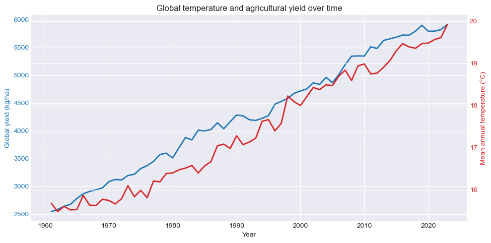

```python
# Visualització de la sèrie temporal global: clima i rendiment
fig, ax1 = plt.subplots(figsize=(10, 5))

# Yield (left axis)
color_yield = "tab:blue"
ax1.plot(
    global_climate_yield_ts["Year"],
    global_climate_yield_ts["yield_kg_ha"],
    color=color_yield,
    linewidth=2
)
ax1.set_xlabel("Year")
ax1.set_ylabel("Global yield (kg/ha)", color=color_yield)
ax1.tick_params(axis="y", labelcolor=color_yield)

# Temperature (right axis)
ax2 = ax1.twinx()
color_temp = "tab:red"
ax2.plot(
    global_climate_yield_ts["Year"],
    global_climate_yield_ts["mean_annual_tas_deg_celsius"],
    color=color_temp,
    linewidth=2
)
ax2.set_ylabel("Mean annual temperature (°C)", color=color_temp)
ax2.tick_params(axis="y", labelcolor=color_temp)

plt.title("Global temperature and agricultural yield over time")
plt.tight_layout()
plt.show()
```

```python
global_climate_yield_ts
```

|  | Year | mean_annual_tas_deg_celsius | yield_kg_ha |
| --- | --- | --- | --- |
| 0 | 1961 | 15.68 | 2544.97 |
| 1 | 1962 | 15.48 | 2585.23 |
| 2 | 1963 | 15.61 | 2640.15 |
| 3 | 1964 | 15.52 | 2676.17 |
| 4 | 1965 | 15.53 | 2782.26 |
| 5 | 1966 | 15.87 | 2865.10 |
| 6 | 1967 | 15.64 | 2909.26 |
| 7 | 1968 | 15.63 | 2936.67 |
| 8 | 1969 | 15.78 | 2971.96 |
| 9 | 1970 | 15.75 | 3083.61 |
| 10 | 1971 | 15.67 | 3122.95 |
| 11 | 1972 | 15.79 | 3115.59 |
| 12 | 1973 | 16.10 | 3195.19 |
| 13 | 1974 | 15.84 | 3216.97 |
| 14 | 1975 | 15.99 | 3319.23 |
| 15 | 1976 | 15.81 | 3373.43 |
| 16 | 1977 | 16.21 | 3447.23 |
| 17 | 1978 | 16.19 | 3573.12 |
| 18 | 1979 | 16.39 | 3596.93 |
| 19 | 1980 | 16.40 | 3511.11 |
| 20 | 1981 | 16.47 | 3698.31 |
| 21 | 1982 | 16.52 | 3879.89 |
| 22 | 1983 | 16.58 | 3835.29 |
| 23 | 1984 | 16.40 | 4010.81 |
| 24 | 1985 | 16.57 | 3997.46 |
| 25 | 1986 | 16.67 | 4024.22 |
| 26 | 1987 | 17.05 | 4144.03 |
| 27 | 1988 | 17.08 | 4036.45 |
| 28 | 1989 | 16.98 | 4163.87 |
| 29 | 1990 | 17.28 | 4282.32 |
| 30 | 1991 | 17.07 | 4269.47 |
| 31 | 1992 | 17.13 | 4199.24 |
| 32 | 1993 | 17.22 | 4186.35 |
| 33 | 1994 | 17.63 | 4224.38 |
| 34 | 1995 | 17.66 | 4271.58 |
| 35 | 1996 | 17.40 | 4478.45 |
| 36 | 1997 | 17.58 | 4528.86 |
| 37 | 1998 | 18.22 | 4583.16 |
| 38 | 1999 | 18.09 | 4673.58 |
| 39 | 2000 | 18.00 | 4716.89 |
| 40 | 2001 | 18.21 | 4753.50 |
| 41 | 2002 | 18.43 | 4864.04 |
| 42 | 2003 | 18.38 | 4833.73 |
| 43 | 2004 | 18.49 | 4962.55 |
| 44 | 2005 | 18.47 | 4864.23 |
| 45 | 2006 | 18.70 | 5011.10 |
| 46 | 2007 | 18.84 | 5190.63 |
| 47 | 2008 | 18.59 | 5342.56 |
| 48 | 2009 | 18.94 | 5347.57 |
| 49 | 2010 | 18.98 | 5345.05 |
| 50 | 2011 | 18.75 | 5510.17 |
| 51 | 2012 | 18.77 | 5481.82 |
| 52 | 2013 | 18.90 | 5625.29 |
| 53 | 2014 | 19.07 | 5655.79 |
| 54 | 2015 | 19.30 | 5685.41 |
| 55 | 2016 | 19.47 | 5723.46 |
| 56 | 2017 | 19.39 | 5720.42 |
| 57 | 2018 | 19.36 | 5793.05 |
| 58 | 2019 | 19.47 | 5898.59 |
| 59 | 2020 | 19.48 | 5792.01 |
| 60 | 2021 | 19.56 | 5793.11 |
| 61 | 2022 | 19.61 | 5821.63 |
| 62 | 2023 | 19.92 | 5913.88 |

## Creació de sèrie temporal global: inputs (fertilizants) i rendiment

Creem un DataFrame global que combina:

- Rendiment global anual (de global_climate_yield_ts)
- Fertilizants per àrea de cultiu (mitjana ponderada per superfície de cultiu)

```python
# Creació del DataFrame global de sèries temporals: inputs (fertilizants) i rendiment

# Calcular fertilitzants globals ponderats per superfície de cultiu
# Filtrar files vàlides: fertilitzants i superfície de cultiu han de ser vàlids i positius
valid_fert_data = agri_country_year_df[
    (agri_country_year_df['fertilizers_per_area_of_cropland_kg_ha'].notna()) &
    (agri_country_year_df['cropland_ha'].notna()) &
    (agri_country_year_df['fertilizers_per_area_of_cropland_kg_ha'] >= 0) &
    (agri_country_year_df['cropland_ha'] > 0)
].copy()

print(f"Files vàlides per al càlcul de fertilitzants: {len(valid_fert_data):,} de {len(agri_country_year_df):,}")

# Calcular fertilitzants ponderats per superfície de cultiu per any
# fert_global = sum(fertilizers * cropland) / sum(cropland)
fert_global_ts = (
    valid_fert_data
    .assign(
        weighted_fert_product=lambda x: x['fertilizers_per_area_of_cropland_kg_ha'] * x['cropland_ha']
    )
    .groupby('Year')
    .agg({
        'weighted_fert_product': 'sum',
        'cropland_ha': 'sum'
    })
    .assign(
        fertilizers_per_area_of_cropland_kg_ha=lambda x: x['weighted_fert_product'] / x['cropland_ha']
    )
    .reset_index()
)

# Eliminar anys amb dades insuficients (sum(cropland_ha) == 0, encara que no hauria de passar després del filtre)
fert_global_ts = fert_global_ts[fert_global_ts['cropland_ha'] > 0].copy()

# Mantenir només Year i fertilizers_per_area_of_cropland_kg_ha
fert_global_ts = fert_global_ts[['Year', 'fertilizers_per_area_of_cropland_kg_ha']].copy()

# Assegurar que Year sigui int
fert_global_ts['Year'] = fert_global_ts['Year'].astype(int)

print(f"Fertilitzants globals (ponderats per superfície de cultiu): {len(fert_global_ts)} anys únics")
print(f"Rang d'anys (fertilitzants): {fert_global_ts['Year'].min()} - {fert_global_ts['Year'].max()}")

# Fusionar amb global_climate_yield_ts per obtenir yield_kg_ha
# Inner join per assegurar que només tenim anys amb dades de tots dos
global_inputs_yield_ts = pd.merge(
    global_climate_yield_ts[['Year', 'yield_kg_ha']],
    fert_global_ts,
    on='Year',
    how='inner'
)

# Mantenir només les columnes necessàries: Year, yield_kg_ha, fertilizers_per_area_of_cropland_kg_ha
global_inputs_yield_ts = global_inputs_yield_ts[['Year', 'yield_kg_ha', 'fertilizers_per_area_of_cropland_kg_ha']].copy()

# Ordenar per any (ascendent)
global_inputs_yield_ts = global_inputs_yield_ts.sort_values('Year').reset_index(drop=True)

# Assegurar que Year sigui int
global_inputs_yield_ts['Year'] = global_inputs_yield_ts['Year'].astype(int)

# Comprovacions
assert global_inputs_yield_ts['Year'].notna().all(), "Error: Hi ha valors nuls en Year"
assert global_inputs_yield_ts['Year'].nunique() == len(global_inputs_yield_ts), "Error: Hi ha anys duplicats"
assert global_inputs_yield_ts['Year'].is_monotonic_increasing, "Error: Els anys no estan ordenats correctament"
assert global_inputs_yield_ts['yield_kg_ha'].notna().all(), "Error: Hi ha valors nuls en yield_kg_ha"
assert global_inputs_yield_ts['fertilizers_per_area_of_cropland_kg_ha'].notna().all(), "Error: Hi ha valors nuls en fertilizers_per_area_of_cropland_kg_ha"

print("\nComprovacions: totes passades")

# Mostrar informació del DataFrame final
print(f"\nDataFrame final: global_inputs_yield_ts")
print(f"Forma: {global_inputs_yield_ts.shape}")
print(f"Columnes: {global_inputs_yield_ts.columns.tolist()}")
print(f"\nNombre d'anys coberts: {len(global_inputs_yield_ts)}")
print(f"Any mínim: {global_inputs_yield_ts['Year'].min()}")
print(f"Any màxim: {global_inputs_yield_ts['Year'].max()}")

print("\nPrimeres files:")
display(global_inputs_yield_ts.head())

print("\nEstadístiques descriptives:")
display(global_inputs_yield_ts.describe())
```

[output not shown]

|  | Year | yield_kg_ha | fertilizers_per_area_of_cropland_kg_ha |
| --- | --- | --- | --- |
| 0 | 1961 | 2544.97 | 23.27 |
| 1 | 1962 | 2585.23 | 25.02 |
| 2 | 1963 | 2640.15 | 27.42 |
| 3 | 1964 | 2676.17 | 29.39 |
| 4 | 1965 | 2782.26 | 32.26 |

```
Estadístiques descriptives:
```

|  | Year | yield_kg_ha | fertilizers_per_area_of_cropland_kg_ha |
| --- | --- | --- | --- |
| count | 63.00 | 63.00 | 63.00 |
| mean | 1992.00 | 4295.26 | 81.20 |
| std | 18.33 | 1035.90 | 27.69 |
| min | 1961.00 | 2544.97 | 23.27 |
| 25% | 1976.50 | 3410.33 | 62.97 |
| 50% | 1992.00 | 4224.38 | 86.21 |
| 75% | 2007.50 | 5266.60 | 100.64 |
| max | 2023.00 | 5913.88 | 123.17 |

```python
# Guardar el DataFrame a disc
output_path = '../data/visualization_input_processed/global_inputs_fertilizers_yield_ts.csv'
global_inputs_yield_ts.to_csv(output_path, index=False)

print(f"DataFrame guardat correctament a: {output_path}")
```

```
DataFrame guardat correctament a: ../data/visualization_input_processed/global_inputs_fertilizers_yield_ts.csv
```

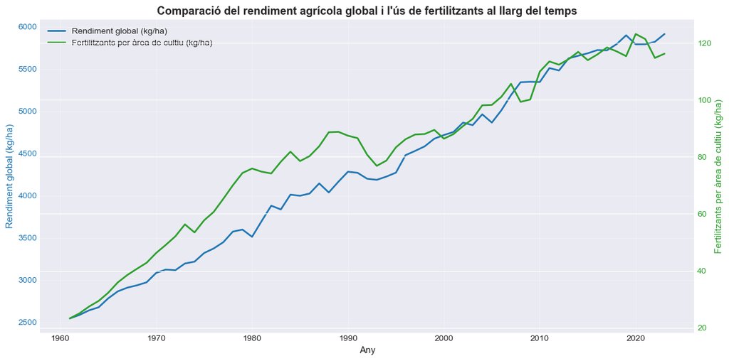

```python
# Visualització exploratòria: comparació de rendiment i fertilitzants en un sol gràfic

fig, ax1 = plt.subplots(figsize=(12, 6))

color1 = 'tab:blue'
color2 = 'tab:green'

# Gràfic de rendiment (eix y primari)
ax1.plot(
    global_inputs_yield_ts['Year'],
    global_inputs_yield_ts['yield_kg_ha'],
    color=color1,
    linewidth=2,
    label='Rendiment global (kg/ha)'
)
ax1.set_xlabel('Any', fontsize=11)
ax1.set_ylabel('Rendiment global (kg/ha)', color=color1, fontsize=11)
ax1.tick_params(axis='y', labelcolor=color1)
ax1.grid(True, alpha=0.3)

# Crear segon eix y per a fertilitzants
ax2 = ax1.twinx()
ax2.plot(
    global_inputs_yield_ts['Year'],
    global_inputs_yield_ts['fertilizers_per_area_of_cropland_kg_ha'],
    color=color2,
    linewidth=2,
    label='Fertilitzants per àrea de cultiu (kg/ha)'
)
ax2.set_ylabel('Fertilitzants per àrea de cultiu (kg/ha)', color=color2, fontsize=11)
ax2.tick_params(axis='y', labelcolor=color2)

# Llegenda combinada per ambdues sèries
lines_1, labels_1 = ax1.get_legend_handles_labels()
lines_2, labels_2 = ax2.get_legend_handles_labels()
ax1.legend(lines_1 + lines_2, labels_1 + labels_2, loc='upper left', fontsize=10)

plt.title('Comparació del rendiment agrícola global i l\'ús de fertilitzants al llarg del temps', fontsize=13, fontweight='bold')
plt.tight_layout()
plt.show()
```

## Creació de sèrie temporal global: emissions i eficiència

Creem un DataFrame global que analitza el cost ambiental de la productivitat agrícola:

- Rendiment global anual (de global_inputs_yield_ts)
- Emissions per hectàrea (intensitat d'emissions agrícoles globals)

```python
# Creació del DataFrame global de sèries temporals: emissions i eficiència

# Calcular emissions globals per hectàrea
# Filtrar files vàlides: emissions i superfície de cultiu han de ser vàlids i positius
valid_emissions_data = agri_country_year_df[
    (agri_country_year_df['emissions_total_agriculture_CO2eq_AR5_kt'].notna()) &
    (agri_country_year_df['cropland_ha'].notna()) &
    (agri_country_year_df['emissions_total_agriculture_CO2eq_AR5_kt'] >= 0) &
    (agri_country_year_df['cropland_ha'] > 0)
].copy()

print(f"Files vàlides per al càlcul d'emissions: {len(valid_emissions_data):,} de {len(agri_country_year_df):,}")

# Agregar per any: sumar emissions totals i superfície de cultiu
emissions_global_ts = (
    valid_emissions_data
    .groupby('Year')
    .agg({
        'emissions_total_agriculture_CO2eq_AR5_kt': 'sum',
        'cropland_ha': 'sum'
    })
    .reset_index()
)

# Calcular emissions per hectàrea: sum(emissions) / sum(cropland)
emissions_global_ts['emissions_per_ha_CO2eq_kt'] = (
    emissions_global_ts['emissions_total_agriculture_CO2eq_AR5_kt'] /
    emissions_global_ts['cropland_ha']
)

# Eliminar anys amb dades insuficients (sum(cropland_ha) == 0)
emissions_global_ts = emissions_global_ts[emissions_global_ts['cropland_ha'] > 0].copy()

# Mantenir només Year i emissions_per_ha_CO2eq_kt
emissions_global_ts = emissions_global_ts[['Year', 'emissions_per_ha_CO2eq_kt']].copy()

# Assegurar que Year sigui int
emissions_global_ts['Year'] = emissions_global_ts['Year'].astype(int)

print(f"Emissions globals per hectàrea: {len(emissions_global_ts)} anys únics")
print(f"Rang d'anys (emissions): {emissions_global_ts['Year'].min()} - {emissions_global_ts['Year'].max()}")

# Fusionar amb global_inputs_yield_ts per obtenir yield_kg_ha
# Inner join per assegurar que només tenim anys amb dades de tots dos
global_emissions_efficiency_ts = pd.merge(
    global_inputs_yield_ts[['Year', 'yield_kg_ha']],
    emissions_global_ts,
    on='Year',
    how='inner'
)

# Mantenir només les columnes necessàries: Year, yield_kg_ha, emissions_per_ha_CO2eq_kt
global_emissions_efficiency_ts = global_emissions_efficiency_ts[
    ['Year', 'yield_kg_ha', 'emissions_per_ha_CO2eq_kt']
].copy()

# Ordenar per any (ascendent)
global_emissions_efficiency_ts = global_emissions_efficiency_ts.sort_values('Year').reset_index(drop=True)

# Assegurar que Year sigui int
global_emissions_efficiency_ts['Year'] = global_emissions_efficiency_ts['Year'].astype(int)

# Comprovacions
assert global_emissions_efficiency_ts['Year'].notna().all(), "Error: Hi ha valors nuls en Year"
assert global_emissions_efficiency_ts['Year'].nunique() == len(global_emissions_efficiency_ts), "Error: Hi ha anys duplicats"
assert global_emissions_efficiency_ts['Year'].is_monotonic_increasing, "Error: Els anys no estan ordenats correctament"
assert global_emissions_efficiency_ts['yield_kg_ha'].notna().all(), "Error: Hi ha valors nuls en yield_kg_ha"
assert global_emissions_efficiency_ts['emissions_per_ha_CO2eq_kt'].notna().all(), "Error: Hi ha valors nuls en emissions_per_ha_CO2eq_kt"

print("\nComprovacions: totes passades")

# Mostrar informació del DataFrame final
print(f"\nDataFrame final: global_emissions_efficiency_ts")
print(f"Forma: {global_emissions_efficiency_ts.shape}")
print(f"Columnes: {global_emissions_efficiency_ts.columns.tolist()}")
print(f"\nNombre d'anys coberts: {len(global_emissions_efficiency_ts)}")
print(f"Any mínim: {global_emissions_efficiency_ts['Year'].min()}")
print(f"Any màxim: {global_emissions_efficiency_ts['Year'].max()}")

print("\nPrimeres files:")
display(global_emissions_efficiency_ts.head())

print("\nEstadístiques descriptives:")
display(global_emissions_efficiency_ts.describe())
```

[output not shown]

|  | Year | yield_kg_ha | emissions_per_ha_CO2eq_kt |
| --- | --- | --- | --- |
| 0 | 1961 | 2544.97 | 1.08e-03 |
| 1 | 1962 | 2585.23 | 1.12e-03 |
| 2 | 1963 | 2640.15 | 1.13e-03 |
| 3 | 1964 | 2676.17 | 1.16e-03 |
| 4 | 1965 | 2782.26 | 1.19e-03 |

```
Estadístiques descriptives:
```

|  | Year | yield_kg_ha | emissions_per_ha_CO2eq_kt |
| --- | --- | --- | --- |
| count | 63.00 | 63.00 | 6.30e+01 |
| mean | 1992.00 | 4295.26 | 1.79e-03 |
| std | 18.33 | 1035.90 | 3.55e-04 |
| min | 1961.00 | 2544.97 | 1.08e-03 |
| 25% | 1976.50 | 3410.33 | 1.54e-03 |
| 50% | 1992.00 | 4224.38 | 1.85e-03 |
| 75% | 2007.50 | 5266.60 | 2.10e-03 |
| max | 2023.00 | 5913.88 | 2.30e-03 |

```python
# Guardar el DataFrame a disc
output_path = '../data/visualization_input_processed/global_emissions_efficiency_ts.csv'
global_emissions_efficiency_ts.to_csv(output_path, index=False)

print(f"DataFrame guardat correctament a: {output_path}")
```

```
DataFrame guardat correctament a: ../data/visualization_input_processed/global_emissions_efficiency_ts.csv
```

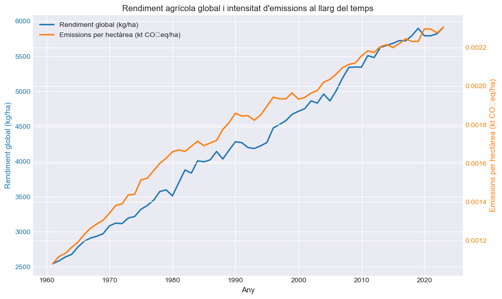

```python
# Visualització exploratòria: rendiment vs emissions per hectàrea

fig, ax1 = plt.subplots(figsize=(10, 6))

color1 = 'tab:blue'
color2 = 'tab:orange'

# Gràfic de rendiment (eix y primari)
ax1.plot(
    global_emissions_efficiency_ts['Year'],
    global_emissions_efficiency_ts['yield_kg_ha'],
    color=color1,
    linewidth=2,
    label='Rendiment global (kg/ha)'
)
ax1.set_xlabel('Any', fontsize=11)
ax1.set_ylabel('Rendiment global (kg/ha)', color=color1, fontsize=11)
ax1.tick_params(axis='y', labelcolor=color1)

# Crear segon eix y per a emissions
ax2 = ax1.twinx()
ax2.plot(
    global_emissions_efficiency_ts['Year'],
    global_emissions_efficiency_ts['emissions_per_ha_CO2eq_kt'],
    color=color2,
    linewidth=2,
    label='Emissions per hectàrea (kt CO₂eq/ha)'
)
ax2.set_ylabel('Emissions per hectàrea (kt CO₂eq/ha)', color=color2, fontsize=11)
ax2.tick_params(axis='y', labelcolor=color2)

# Llegenda combinada per ambdues sèries
lines_1, labels_1 = ax1.get_legend_handles_labels()
lines_2, labels_2 = ax2.get_legend_handles_labels()
ax1.legend(lines_1 + lines_2, labels_1 + labels_2, loc='upper left', fontsize=10)

plt.title('Rendiment agrícola global i intensitat d\'emissions al llarg del temps', fontsize=12)
plt.tight_layout()
plt.show()
```

## Índex de Vulnerabilitat Climàtica Agrícola

Creem un índex de vulnerabilitat que combina:

- Estrès climàtic (temperatura i precipitació)
- Dependència econòmica (pes de l'agricultura al PIB)
- Exposició social (població rural)

```python
# Creació de l'índex de vulnerabilitat climàtica agrícola per país

# Definir períodes
baseline_start = 1961
baseline_end = 1990
recent_start = 2014
recent_end = 2023

print(f"Període de referència (baseline): {baseline_start}-{baseline_end}")
print(f"Període recent: {recent_start}-{recent_end}")

# Filtrar dades per període de referència (precipitació baseline)
baseline_data = agri_country_year_df[
    (agri_country_year_df['Year'] >= baseline_start) &
    (agri_country_year_df['Year'] <= baseline_end)
].copy()

# Filtrar dades per període recent
recent_data = agri_country_year_df[
    (agri_country_year_df['Year'] >= recent_start) &
    (agri_country_year_df['Year'] <= recent_end)
].copy()

print(f"\nFiles al període baseline: {len(baseline_data):,}")
print(f"Files al període recent: {len(recent_data):,}")

# Calcular mitjanes per país al període recent
recent_avg = (
    recent_data
    .groupby(['ISO3', 'Country'])
    .agg({
        'surface_temperature_change_celsius': 'mean',
        'prec_mm_per_year': 'mean',
        'agriculture_share_gdp_percent': 'mean',
        'rural_population_%': 'mean'
    })
    .reset_index()
    .rename(columns={
        'surface_temperature_change_celsius': 'temp_recent_avg',
        'prec_mm_per_year': 'recent_prec',
        'agriculture_share_gdp_percent': 'agriculture_share_gdp_recent_avg',
        'rural_population_%': 'rural_population_recent_avg'
    })
)

# Calcular precipitació baseline per país
baseline_prec = (
    baseline_data
    .groupby(['ISO3', 'Country'])
    .agg({
        'prec_mm_per_year': 'mean'
    })
    .reset_index()
    .rename(columns={'prec_mm_per_year': 'baseline_prec'})
)

# Fusionar dades recent i baseline
country_vulnerability_df = pd.merge(
    recent_avg,
    baseline_prec,
    on=['ISO3', 'Country'],
    how='inner'
)

# Calcular estrès de precipitació (desviació absoluta respecte al baseline)
country_vulnerability_df['prec_stress'] = abs(
    country_vulnerability_df['recent_prec'] - country_vulnerability_df['baseline_prec']
)

# Afegir informació del període
country_vulnerability_df['recent_period_start'] = recent_start
country_vulnerability_df['recent_period_end'] = recent_end

print(f"\nPaïsos amb dades completes: {len(country_vulnerability_df)}")

# Eliminar països amb valors nuls en qualsevol component necessari
required_cols = [
    'temp_recent_avg', 'baseline_prec', 'recent_prec', 'prec_stress',
    'agriculture_share_gdp_recent_avg', 'rural_population_recent_avg'
]

country_vulnerability_df = country_vulnerability_df.dropna(subset=required_cols)

print(f"Països després d'eliminar valors nuls: {len(country_vulnerability_df)}")

country_vulnerability_df['temp_z'] = stats.zscore(country_vulnerability_df['temp_recent_avg'], nan_policy='omit')
country_vulnerability_df['prec_z'] = stats.zscore(country_vulnerability_df['prec_stress'], nan_policy='omit')
country_vulnerability_df['agdep_z'] = stats.zscore(country_vulnerability_df['agriculture_share_gdp_recent_avg'], nan_policy='omit')
country_vulnerability_df['rural_z'] = stats.zscore(country_vulnerability_df['rural_population_recent_avg'], nan_policy='omit')

# Eliminar qualsevol fila amb z-scores nuls (hauria de ser rar després de dropna)
country_vulnerability_df = country_vulnerability_df.dropna(subset=['temp_z', 'prec_z', 'agdep_z', 'rural_z'])

print(f"Països finals amb tots els components: {len(country_vulnerability_df)}")

# Calcular índex de vulnerabilitat (suma ponderada)
country_vulnerability_df['vulnerability_index'] = (
    0.35 * country_vulnerability_df['temp_z'] +
    0.25 * country_vulnerability_df['prec_z'] +
    0.25 * country_vulnerability_df['agdep_z'] +
    0.15 * country_vulnerability_df['rural_z']
)

# Escalar a 0-100
vuln_min = country_vulnerability_df['vulnerability_index'].min()
vuln_max = country_vulnerability_df['vulnerability_index'].max()
country_vulnerability_df['vulnerability_0_100'] = (
    (country_vulnerability_df['vulnerability_index'] - vuln_min) /
    (vuln_max - vuln_min) * 100
)

# Ordenar per vulnerabilitat descendent
country_vulnerability_df = country_vulnerability_df.sort_values(
    'vulnerability_0_100',
    ascending=False
).reset_index(drop=True)

# Reordenar columnes segons especificació
column_order = [
    'ISO3', 'Country',
    'recent_period_start', 'recent_period_end',
    'temp_recent_avg', 'baseline_prec', 'recent_prec', 'prec_stress',
    'agriculture_share_gdp_recent_avg', 'rural_population_recent_avg',
    'temp_z', 'prec_z', 'agdep_z', 'rural_z',
    'vulnerability_index', 'vulnerability_0_100'
]

country_vulnerability_df = country_vulnerability_df[column_order]

# Comprovacions
assert country_vulnerability_df['vulnerability_0_100'].min() >= 0, "Error: vulnerabilitat mínima < 0"
assert country_vulnerability_df['vulnerability_0_100'].max() <= 100, "Error: vulnerabilitat màxima > 100"
assert country_vulnerability_df['ISO3'].nunique() == len(country_vulnerability_df), "Error: ISO3 duplicats"

print("\nComprovacions: totes passades")

# Mostrar informació
print(f"\nDataFrame final: country_vulnerability_df")
print(f"Nombre de països: {len(country_vulnerability_df)}")
print(f"\nPrimeres files:")
display(country_vulnerability_df.head(10))

print(f"\nTop 10 països més vulnerables:")
top_10 = country_vulnerability_df[['Country', 'vulnerability_0_100']].head(10)
for idx, row in top_10.iterrows():
    print(f"  {row['Country']}: {row['vulnerability_0_100']:.2f}")
```

[output not shown]

|  | ISO3 | Country | recent_period_start | recent_period_end | temp_recent_avg | baseline_prec | recent_prec | prec_stress | agriculture_share_gdp_recent_avg | rural_population_recent_avg | temp_z | prec_z | agdep_z | rural_z | vulnerability_index | vulnerability_0_100 |
| --- | --- | --- | --- | --- | --- | --- | --- | --- | --- | --- | --- | --- | --- | --- | --- | --- |
| 0 | GNB | Guinea-Bissau | 2014 | 2023 | 1.38 | 1555.34 | 1710.60 | 155.26 | 35.36 | 0.56 | 0.19 | 1.66 | 2.33 | 0.76 | 1.18 | 100.00 |
| 1 | TON | Tonga | 2014 | 2023 | 1.06 | 1440.72 | 1718.60 | 277.88 | 16.99 | 0.77 | -0.56 | 3.75 | 0.60 | 1.63 | 1.14 | 98.48 |
| 2 | SOM | Somalia | 2014 | 2023 | 1.42 | 282.06 | 299.75 | 17.69 | 55.79 | 0.55 | 0.29 | -0.69 | 4.26 | 0.68 | 1.10 | 97.09 |
| 3 | PRK | Democratic People's Republic of Korea | 2014 | 2023 | 1.64 | 1029.14 | 991.81 | 37.33 | 40.49 | 0.38 | 0.80 | -0.35 | 2.82 | -0.03 | 0.89 | 89.18 |
| 4 | KEN | Kenya | 2014 | 2023 | 1.17 | 725.05 | 901.30 | 176.25 | 20.69 | 0.73 | -0.29 | 2.02 | 0.95 | 1.45 | 0.86 | 87.93 |
| 5 | BGD | Bangladesh | 2014 | 2023 | 1.26 | 2329.93 | 2112.75 | 217.19 | 12.69 | 0.63 | -0.08 | 2.72 | 0.19 | 1.04 | 0.85 | 87.82 |
| 6 | SYR | Syrian Arab Republic | 2014 | 2023 | 1.70 | 314.37 | 293.33 | 21.03 | 37.47 | 0.46 | 0.94 | -0.63 | 2.53 | 0.29 | 0.85 | 87.58 |
| 7 | GUY | Guyana | 2014 | 2023 | 1.54 | 2374.88 | 2474.00 | 99.12 | 18.04 | 0.73 | 0.57 | 0.70 | 0.70 | 1.48 | 0.77 | 84.67 |
| 8 | PHL | Philippines | 2014 | 2023 | 1.27 | 2452.37 | 2670.18 | 217.81 | 10.13 | 0.53 | -0.05 | 2.73 | -0.05 | 0.61 | 0.74 | 83.55 |
| 9 | AUT | Austria | 2014 | 2023 | 2.23 | 1079.87 | 1181.22 | 101.35 | 1.19 | 0.42 | 2.15 | 0.74 | -0.89 | 0.12 | 0.73 | 83.28 |

```
Top 10 països més vulnerables:
  Guinea-Bissau: 100.00
  Tonga: 98.48
  Somalia: 97.09
  Democratic People's Republic of Korea: 89.18
  Kenya: 87.93
  Bangladesh: 87.82
  Syrian Arab Republic: 87.58
  Guyana: 84.67
  Philippines: 83.55
  Austria: 83.28
```

```python
# Guardar el DataFrame a disc
output_path = '../data/visualization_input_processed/country_vulnerability_df.csv'
country_vulnerability_df.to_csv(output_path, index=False)

print(f"DataFrame guardat correctament a: {output_path}")
print(f"Fitxer creat amb {len(country_vulnerability_df)} files i {len(country_vulnerability_df.columns)} columnes")
```

```
DataFrame guardat correctament a: ../data/visualization_input_processed/country_vulnerability_df.csv
Fitxer creat amb 153 files i 16 columnes
```

```python
# Visualització: mapa coroplètic de vulnerabilitat climàtica agrícola

fig = px.choropleth(
    country_vulnerability_df,
    locations="ISO3",
    color="vulnerability_0_100",
    hover_name="Country",
    hover_data=[
        'temp_recent_avg',
        'prec_stress',
        'agriculture_share_gdp_recent_avg',
        'rural_population_recent_avg',
        'vulnerability_0_100'
    ],
    title="Agricultural Climate Vulnerability Index (Recent vs Baseline)",
    color_continuous_scale='RdYlBu_r',  # Red-Yellow-Blue reversed (red = high vulnerability)
    labels={'vulnerability_0_100': 'Vulnerability Index (0-100)'}
)

fig.update_layout(
    geo=dict(
        showframe=False,
        showcoastlines=True,
        projection_type='natural earth'
    ),
    height=600
)

fig.show()

print(f"\nNombre de països inclosos al mapa: {len(country_vulnerability_df)}")
print(f"\nTop 10 països més vulnerables:")
display(country_vulnerability_df[['Country', 'vulnerability_0_100']].head(10))
print(f"\nTop 10 països menys vulnerables:")
display(country_vulnerability_df[['Country', 'vulnerability_0_100']].tail(10))
```

[output not shown]

```
Nombre de països inclosos al mapa: 153

Top 10 països més vulnerables:
```

|  | Country | vulnerability_0_100 |
| --- | --- | --- |
| 0 | Guinea-Bissau | 100.00 |
| 1 | Tonga | 98.48 |
| 2 | Somalia | 97.09 |
| 3 | Democratic People's Republic of Korea | 89.18 |
| 4 | Kenya | 87.93 |
| 5 | Bangladesh | 87.82 |
| 6 | Syrian Arab Republic | 87.58 |
| 7 | Guyana | 84.67 |
| 8 | Philippines | 83.55 |
| 9 | Austria | 83.28 |

```
Top 10 països menys vulnerables:
```

|  | Country | vulnerability_0_100 |
| --- | --- | --- |
| 143 | Guadeloupe | 31.71 |
| 144 | Uruguay | 28.57 |
| 145 | Botswana | 28.24 |
| 146 | Côte d'Ivoire | 27.88 |
| 147 | Australia | 26.75 |
| 148 | New Zealand | 25.09 |
| 149 | Argentina | 22.67 |
| 150 | Réunion | 20.88 |
| 151 | Türkiye | 17.59 |
| 152 | Bermuda | 0.00 |

## Índex d'Eficiència Agrícola Sostenible

Creem un índex d'eficiencia que combina:

- Alt rendiment (kg/ha)
- Baix ús de fertilitzants (kg/ha)
- Baixes emissions (kt CO₂eq/ha)

```python
# Creació de l'índex d'eficiencia agrícola sostenible per país

# Utilitzem el mateix període recent (2014-2023 o últims 10 anys disponibles)

print(f"Període recent utilitzat: {recent_start}-{recent_end}")

# A) Calcular rendiment per país (ponderat per àrea de cultiu)
print("\nCalculant rendiment per país...")

# Filtrar dades de producció del període recent
prod_recent = agri_production_prices_df[
    (agri_production_prices_df['Year'] >= recent_start) &
    (agri_production_prices_df['Year'] <= recent_end)
].copy()

# Filtrar files vàlides
prod_recent = prod_recent[
    (prod_recent['area_harvested_ha'].notna()) &
    (prod_recent['production_kt'].notna()) &
    (prod_recent['area_harvested_ha'] > 0) &
    (prod_recent['production_kt'] > 0)
].copy()

# Agregar duplicats a nivell ISO3-Year-Commodity
prod_agg = (
    prod_recent
    .groupby(['ISO3', 'Country', 'Year', 'Commodity'])
    .agg({
        'area_harvested_ha': 'sum',
        'production_kt': 'sum'
    })
    .reset_index()
)

# Recalcular yield després de l'agregació
prod_agg['yield_kg_ha'] = (prod_agg['production_kt'] * 1_000_000) / prod_agg['area_harvested_ha']

# Filtrar files amb yield vàlid i positiu
prod_agg = prod_agg[
    (prod_agg['yield_kg_ha'].notna()) &
    (prod_agg['yield_kg_ha'] > 0)
].copy()

# Calcular rendiment ponderat per àrea per país-any
yield_country_year = (
    prod_agg
    .assign(
        weighted_yield_product=lambda x: x['yield_kg_ha'] * x['area_harvested_ha']
    )
    .groupby(['ISO3', 'Country', 'Year'])
    .agg({
        'weighted_yield_product': 'sum',
        'area_harvested_ha': 'sum'
    })
    .assign(
        yield_country_year=lambda x: x['weighted_yield_product'] / x['area_harvested_ha']
    )
    .reset_index()
    [['ISO3', 'Country', 'Year', 'yield_country_year']]
)

# Mitjana per país al període recent
yield_recent_avg = (
    yield_country_year
    .groupby(['ISO3', 'Country'])
    .agg({
        'yield_country_year': 'mean'
    })
    .reset_index()
    .rename(columns={'yield_country_year': 'yield_recent_avg_kg_ha'})
)

print(f"Països amb dades de rendiment: {len(yield_recent_avg)}")

# B) Calcular fertilitzants per país (mitjana recent)
print("\nCalculant fertilitzants per país...")

fert_recent = agri_country_year_df[
    (agri_country_year_df['Year'] >= recent_start) &
    (agri_country_year_df['Year'] <= recent_end) &
    (agri_country_year_df['fertilizers_per_area_of_cropland_kg_ha'].notna()) &
    (agri_country_year_df['fertilizers_per_area_of_cropland_kg_ha'] >= 0)
].copy()

fertilizers_recent_avg = (
    fert_recent
    .groupby(['ISO3', 'Country'])
    .agg({
        'fertilizers_per_area_of_cropland_kg_ha': 'mean'
    })
    .reset_index()
    .rename(columns={'fertilizers_per_area_of_cropland_kg_ha': 'fertilizers_recent_avg_kg_ha'})
)

print(f"Països amb dades de fertilitzants: {len(fertilizers_recent_avg)}")

# C) Calcular emissions per hectàrea per país (mitjana recent)
print("\nCalculant emissions per país...")

emis_recent = agri_country_year_df[
    (agri_country_year_df['Year'] >= recent_start) &
    (agri_country_year_df['Year'] <= recent_end) &
    (agri_country_year_df['emissions_total_agriculture_CO2eq_AR5_kt'].notna()) &
    (agri_country_year_df['cropland_ha'].notna()) &
    (agri_country_year_df['emissions_total_agriculture_CO2eq_AR5_kt'] >= 0) &
    (agri_country_year_df['cropland_ha'] > 0)
].copy()

# Calcular emissions per hectàrea per país-any
emis_per_ha = emis_recent.copy()
emis_per_ha['emissions_per_ha'] = (
    emis_per_ha['emissions_total_agriculture_CO2eq_AR5_kt'] /
    emis_per_ha['cropland_ha']
)

emissions_recent_avg = (
    emis_per_ha
    .groupby(['ISO3', 'Country'])
    .agg({
        'emissions_per_ha': 'mean'
    })
    .reset_index()
    .rename(columns={'emissions_per_ha': 'emissions_recent_avg_kt_per_ha'})
)

print(f"Països amb dades d'emissions: {len(emissions_recent_avg)}")

# D) Opcional: agriculture_share_gdp_percent
print("\nCalculant pes de l'agricultura al PIB...")

gdp_recent = agri_country_year_df[
    (agri_country_year_df['Year'] >= recent_start) &
    (agri_country_year_df['Year'] <= recent_end) &
    (agri_country_year_df['agriculture_share_gdp_percent'].notna())
].copy()

agriculture_share_gdp_recent_avg = (
    gdp_recent
    .groupby(['ISO3', 'Country'])
    .agg({
        'agriculture_share_gdp_percent': 'mean'
    })
    .reset_index()
    .rename(columns={'agriculture_share_gdp_percent': 'agriculture_share_gdp_recent_avg'})
)

print(f"Països amb dades de PIB agrícola: {len(agriculture_share_gdp_recent_avg)}")

# Fusionar totes les mètriques
country_efficiency_df = yield_recent_avg.copy()

country_efficiency_df = pd.merge(
    country_efficiency_df,
    fertilizers_recent_avg,
    on=['ISO3', 'Country'],
    how='inner'
)

country_efficiency_df = pd.merge(
    country_efficiency_df,
    emissions_recent_avg,
    on=['ISO3', 'Country'],
    how='inner'
)

# Afegir PIB agrícola (opcional, left join)
country_efficiency_df = pd.merge(
    country_efficiency_df,
    agriculture_share_gdp_recent_avg,
    on=['ISO3', 'Country'],
    how='left'
)

# Afegir informació del període
country_efficiency_df['recent_period_start'] = recent_start
country_efficiency_df['recent_period_end'] = recent_end

# Eliminar països amb valors nuls en les mètriques principals
required_cols = ['yield_recent_avg_kg_ha', 'fertilizers_recent_avg_kg_ha', 'emissions_recent_avg_kt_per_ha']
country_efficiency_df = country_efficiency_df.dropna(subset=required_cols)

# Assegurar que no hi ha valors nuls en ISO3/Country
country_efficiency_df = country_efficiency_df[
    country_efficiency_df['ISO3'].notna() &
    country_efficiency_df['Country'].notna()
].copy()

print(f"\nPaïsos finals amb totes les mètriques: {len(country_efficiency_df)}")

country_efficiency_df['yield_z'] = stats.zscore(country_efficiency_df['yield_recent_avg_kg_ha'], nan_policy='omit')
country_efficiency_df['fert_z'] = stats.zscore(country_efficiency_df['fertilizers_recent_avg_kg_ha'], nan_policy='omit')
country_efficiency_df['emis_z'] = stats.zscore(country_efficiency_df['emissions_recent_avg_kt_per_ha'], nan_policy='omit')

# Eliminar files amb z-scores nuls
country_efficiency_df = country_efficiency_df.dropna(subset=['yield_z', 'fert_z', 'emis_z'])

# Calcular índex d'eficiencia
# Alt rendiment és bo (+), alt fertilitzant és dolent (-), altes emissions són dolentes (-)
country_efficiency_df['efficiency_index'] = (
    0.45 * country_efficiency_df['yield_z'] -
    0.30 * country_efficiency_df['fert_z'] -
    0.25 * country_efficiency_df['emis_z']
)

# Escalar a 0-100
eff_min = country_efficiency_df['efficiency_index'].min()
eff_max = country_efficiency_df['efficiency_index'].max()
country_efficiency_df['efficiency_0_100'] = (
    (country_efficiency_df['efficiency_index'] - eff_min) /
    (eff_max - eff_min) * 100
)

# Ordenar per eficiencia descendent
country_efficiency_df = country_efficiency_df.sort_values(
    'efficiency_0_100',
    ascending=False
).reset_index(drop=True)

# Reordenar columnes segons especificació
column_order = [
    'ISO3', 'Country',
    'recent_period_start', 'recent_period_end',
    'yield_recent_avg_kg_ha',
    'fertilizers_recent_avg_kg_ha',
    'emissions_recent_avg_kt_per_ha',
    'agriculture_share_gdp_recent_avg',
    'yield_z', 'fert_z', 'emis_z',
    'efficiency_index', 'efficiency_0_100'
]

# Mantenir només les columnes que existeixen
column_order = [col for col in column_order if col in country_efficiency_df.columns]
country_efficiency_df = country_efficiency_df[column_order]

# Comprovacions
assert country_efficiency_df['efficiency_0_100'].min() >= 0, "Error: eficiencia mínima < 0"
assert country_efficiency_df['efficiency_0_100'].max() <= 100, "Error: eficiencia màxima > 100"
assert country_efficiency_df['ISO3'].nunique() == len(country_efficiency_df), "Error: ISO3 duplicats"

print("\nComprovacions: totes passades")

# Mostrar informació
print(f"\nDataFrame final: country_efficiency_df")
print(f"Nombre de països: {len(country_efficiency_df)}")
print(f"\nPrimeres files (més eficients):")
display(country_efficiency_df.head(10))

print(f"\nÚltimes files (menys eficients):")
display(country_efficiency_df.tail(10))
```

```
Període recent utilitzat: 2014-2023

Calculant rendiment per país...
Països amb dades de rendiment: 198

Calculant fertilitzants per país...
Països amb dades de fertilitzants: 203

Calculant emissions per país...
Països amb dades d'emissions: 202

Calculant pes de l'agricultura al PIB...
Països amb dades de PIB agrícola: 203

Països finals amb totes les mètriques: 195

Comprovacions: totes passades

DataFrame final: country_efficiency_df
Nombre de països: 195

Primeres files (més eficients):
```

|  | ISO3 | Country | recent_period_start | recent_period_end | yield_recent_avg_kg_ha | fertilizers_recent_avg_kg_ha | emissions_recent_avg_kt_per_ha | agriculture_share_gdp_recent_avg | yield_z | fert_z | emis_z | efficiency_index | efficiency_0_100 |
| --- | --- | --- | --- | --- | --- | --- | --- | --- | --- | --- | --- | --- | --- |
| 0 | MUS | Mauritius | 2014 | 2023 | 59102.46 | 187.46 | 1.95e-03 | 3.16 | 7.05 | 1.09 | -0.21 | 2.90 | 100.00 |
| 1 | SWZ | Eswatini | 2014 | 2023 | 31974.83 | 66.36 | 2.08e-03 | 7.31 | 3.36 | -0.23 | -0.19 | 1.63 | 78.31 |
| 2 | NLD | Netherlands (Kingdom of the) | 2014 | 2023 | 38367.02 | 142.65 | 6.35e-03 | 1.77 | 4.23 | 0.60 | 0.52 | 1.59 | 77.70 |
| 3 | FJI | Fiji | 2014 | 2023 | 27881.89 | 53.03 | 1.34e-03 | 11.34 | 2.80 | -0.38 | -0.31 | 1.45 | 75.31 |
| 4 | BRB | Barbados | 2014 | 2023 | 23194.70 | 67.19 | 3.45e-03 | 2.14 | 2.16 | -0.22 | 0.04 | 1.03 | 68.11 |
| 5 | CUB | Cuba | 2014 | 2023 | 15680.80 | 23.43 | 1.16e-03 | 2.86 | 1.14 | -0.70 | -0.34 | 0.81 | 64.34 |
| 6 | JAM | Jamaica | 2014 | 2023 | 16204.91 | 45.01 | 1.39e-03 | 7.33 | 1.21 | -0.47 | -0.30 | 0.76 | 63.51 |
| 7 | PRI | Puerto Rico | 2014 | 2023 | 16276.68 | 39.76 | 2.35e-03 | 0.74 | 1.22 | -0.52 | -0.14 | 0.74 | 63.20 |
| 8 | GTM | Guatemala | 2014 | 2023 | 17175.61 | 111.92 | 1.75e-03 | 9.61 | 1.34 | 0.26 | -0.24 | 0.58 | 60.53 |
| 9 | SLV | El Salvador | 2014 | 2023 | 13609.99 | 69.91 | 1.32e-03 | 5.20 | 0.85 | -0.19 | -0.31 | 0.52 | 59.46 |

```
Últimes files (menys eficients):
```

|  | ISO3 | Country | recent_period_start | recent_period_end | yield_recent_avg_kg_ha | fertilizers_recent_avg_kg_ha | emissions_recent_avg_kt_per_ha | agriculture_share_gdp_recent_avg | yield_z | fert_z | emis_z | efficiency_index | efficiency_0_100 |
| --- | --- | --- | --- | --- | --- | --- | --- | --- | --- | --- | --- | --- | --- |
| 185 | SUR | Suriname | 2014 | 2023 | 7038.63 | 181.86 | 1.03e-02 | 9.27 | -0.04 | 1.03 | 1.18 | -0.62 | 39.96 |
| 186 | VNM | Viet Nam | 2014 | 2023 | 8069.03 | 259.04 | 5.80e-03 | 12.92 | 0.10 | 1.87 | 0.43 | -0.63 | 39.90 |
| 187 | NCL | New Caledonia | 2014 | 2023 | 2442.93 | 154.09 | 6.29e-03 | 1.85 | -0.67 | 0.73 | 0.52 | -0.65 | 39.54 |
| 188 | EGY | Egypt | 2014 | 2023 | 15641.93 | 417.35 | 6.58e-03 | 11.12 | 1.13 | 3.60 | 0.56 | -0.71 | 38.41 |
| 189 | CHN | China | 2014 | 2023 | 9205.01 | 375.97 | 4.84e-03 | 7.45 | 0.25 | 3.15 | 0.27 | -0.90 | 35.23 |
| 190 | BGD | Bangladesh | 2014 | 2023 | 5433.53 | 297.56 | 7.40e-03 | 12.69 | -0.26 | 2.29 | 0.70 | -0.98 | 33.86 |
| 191 | TKM | Turkmenistan | 2014 | 2023 | 2244.45 | 277.80 | 4.50e-03 | 10.66 | -0.69 | 2.08 | 0.22 | -0.99 | 33.69 |
| 192 | TWN | Taiwan | 2014 | 2023 | 11477.00 | 461.80 | 4.71e-03 | 0.07 | 0.56 | 4.09 | 0.25 | -1.04 | 32.90 |
| 193 | IRL | Ireland | 2014 | 2023 | 9343.44 | 286.13 | 2.05e-02 | 0.97 | 0.27 | 2.17 | 2.88 | -1.25 | 29.28 |
| 194 | DJI | Djibouti | 2014 | 2023 | 1897.62 | 21.51 | 7.16e-02 | 1.76 | -0.74 | -0.72 | 11.39 | -2.96 | 0.00 |

```python
# Mostrar top 10 més eficients i menys eficients amb les 3 mètriques

print("Top 10 països més eficients:")
top_10_efficient = country_efficiency_df[['Country', 'efficiency_0_100', 'yield_recent_avg_kg_ha',
                                          'fertilizers_recent_avg_kg_ha', 'emissions_recent_avg_kt_per_ha']].head(10)
for idx, row in top_10_efficient.iterrows():
    print(f"  {row['Country']}: Eficiencia={row['efficiency_0_100']:.2f}, "
          f"Rendiment={row['yield_recent_avg_kg_ha']:.1f} kg/ha, "
          f"Fertilitzants={row['fertilizers_recent_avg_kg_ha']:.1f} kg/ha, "
          f"Emissions={row['emissions_recent_avg_kt_per_ha']:.4f} kt/ha")

print("\nTop 10 països menys eficients:")
bottom_10_efficient = country_efficiency_df[['Country', 'efficiency_0_100', 'yield_recent_avg_kg_ha',
                                              'fertilizers_recent_avg_kg_ha', 'emissions_recent_avg_kt_per_ha']].tail(10)
for idx, row in bottom_10_efficient.iterrows():
    print(f"  {row['Country']}: Eficiencia={row['efficiency_0_100']:.2f}, "
          f"Rendiment={row['yield_recent_avg_kg_ha']:.1f} kg/ha, "
          f"Fertilitzants={row['fertilizers_recent_avg_kg_ha']:.1f} kg/ha, "
          f"Emissions={row['emissions_recent_avg_kt_per_ha']:.4f} kt/ha")
```

```
Top 10 països més eficients:
  Mauritius: Eficiencia=100.00, Rendiment=59102.5 kg/ha, Fertilitzants=187.5 kg/ha, Emissions=0.0020 kt/ha
  Eswatini: Eficiencia=78.31, Rendiment=31974.8 kg/ha, Fertilitzants=66.4 kg/ha, Emissions=0.0021 kt/ha
  Netherlands (Kingdom of the): Eficiencia=77.70, Rendiment=38367.0 kg/ha, Fertilitzants=142.6 kg/ha, Emissions=0.0064 kt/ha
  Fiji: Eficiencia=75.31, Rendiment=27881.9 kg/ha, Fertilitzants=53.0 kg/ha, Emissions=0.0013 kt/ha
  Barbados: Eficiencia=68.11, Rendiment=23194.7 kg/ha, Fertilitzants=67.2 kg/ha, Emissions=0.0035 kt/ha
  Cuba: Eficiencia=64.34, Rendiment=15680.8 kg/ha, Fertilitzants=23.4 kg/ha, Emissions=0.0012 kt/ha
  Jamaica: Eficiencia=63.51, Rendiment=16204.9 kg/ha, Fertilitzants=45.0 kg/ha, Emissions=0.0014 kt/ha
  Puerto Rico: Eficiencia=63.20, Rendiment=16276.7 kg/ha, Fertilitzants=39.8 kg/ha, Emissions=0.0023 kt/ha
  Guatemala: Eficiencia=60.53, Rendiment=17175.6 kg/ha, Fertilitzants=111.9 kg/ha, Emissions=0.0017 kt/ha
  El Salvador: Eficiencia=59.46, Rendiment=13610.0 kg/ha, Fertilitzants=69.9 kg/ha, Emissions=0.0013 kt/ha

Top 10 països menys eficients:
  Suriname: Eficiencia=39.96, Rendiment=7038.6 kg/ha, Fertilitzants=181.9 kg/ha, Emissions=0.0103 kt/ha
  Viet Nam: Eficiencia=39.90, Rendiment=8069.0 kg/ha, Fertilitzants=259.0 kg/ha, Emissions=0.0058 kt/ha
  New Caledonia: Eficiencia=39.54, Rendiment=2442.9 kg/ha, Fertilitzants=154.1 kg/ha, Emissions=0.0063 kt/ha
  Egypt: Eficiencia=38.41, Rendiment=15641.9 kg/ha, Fertilitzants=417.4 kg/ha, Emissions=0.0066 kt/ha
  China: Eficiencia=35.23, Rendiment=9205.0 kg/ha, Fertilitzants=376.0 kg/ha, Emissions=0.0048 kt/ha
  Bangladesh: Eficiencia=33.86, Rendiment=5433.5 kg/ha, Fertilitzants=297.6 kg/ha, Emissions=0.0074 kt/ha
  Turkmenistan: Eficiencia=33.69, Rendiment=2244.5 kg/ha, Fertilitzants=277.8 kg/ha, Emissions=0.0045 kt/ha
  Taiwan: Eficiencia=32.90, Rendiment=11477.0 kg/ha, Fertilitzants=461.8 kg/ha, Emissions=0.0047 kt/ha
  Ireland: Eficiencia=29.28, Rendiment=9343.4 kg/ha, Fertilitzants=286.1 kg/ha, Emissions=0.0205 kt/ha
  Djibouti: Eficiencia=0.00, Rendiment=1897.6 kg/ha, Fertilitzants=21.5 kg/ha, Emissions=0.0716 kt/ha
```

```python
# Guardar el DataFrame a disc
output_path = '../data/visualization_input_processed/country_efficiency_df.csv'
country_efficiency_df.to_csv(output_path, index=False)

print(f"DataFrame guardat correctament a: {output_path}")
print(f"Fitxer creat amb {len(country_efficiency_df)} files i {len(country_efficiency_df.columns)} columnes")
```

```
DataFrame guardat correctament a: ../data/visualization_input_processed/country_efficiency_df.csv
Fitxer creat amb 195 files i 13 columnes
```

```python
# Visualització: mapa coroplètic d'eficiencia agrícola

fig = px.choropleth(
    country_efficiency_df,
    locations="ISO3",
    color="efficiency_0_100",
    hover_name="Country",
    hover_data=[
        'yield_recent_avg_kg_ha',
        'fertilizers_recent_avg_kg_ha',
        'emissions_recent_avg_kt_per_ha',
        'efficiency_0_100'
    ],
    title="Agricultural Efficiency Index (High yield, low inputs, low emissions)",
    color_continuous_scale='RdYlGn',  # Red-Yellow-Green (green = high efficiency)
    labels={'efficiency_0_100': 'Efficiency Index (0-100)'}
)

fig.update_layout(
    geo=dict(
        showframe=False,
        showcoastlines=True,
        projection_type='natural earth'
    ),
    height=600
)

fig.show()

print(f"\nNombre de països inclosos al mapa: {len(country_efficiency_df)}")
```

[output not shown]

```
Nombre de països inclosos al mapa: 195
```

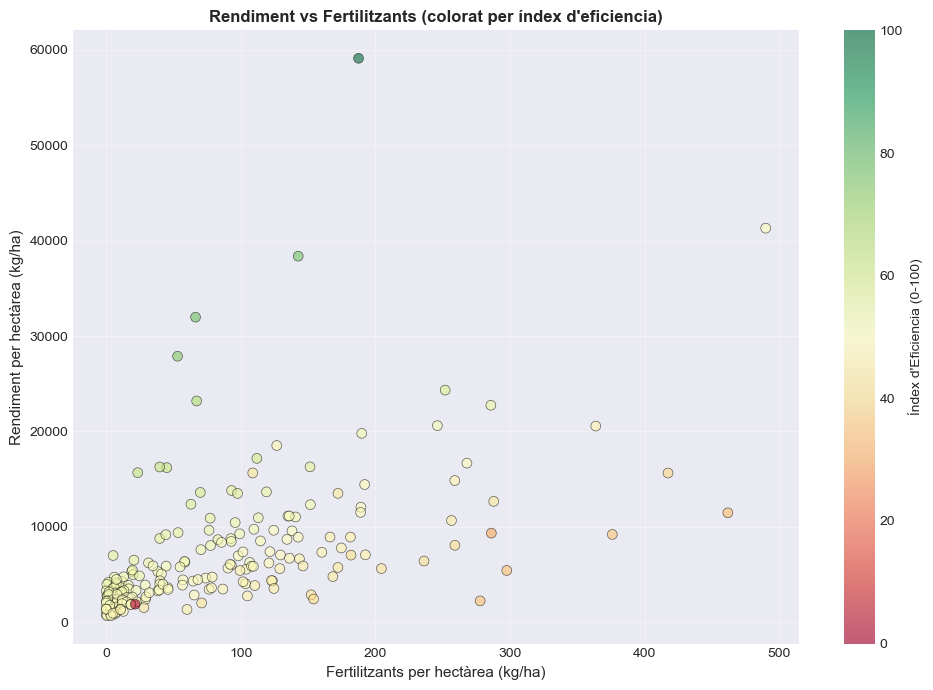

```python
# Visualització exploratòria: scatter plot rendiment vs fertilitzants

fig, ax = plt.subplots(figsize=(10, 7))

scatter = ax.scatter(
    country_efficiency_df['fertilizers_recent_avg_kg_ha'],
    country_efficiency_df['yield_recent_avg_kg_ha'],
    c=country_efficiency_df['efficiency_0_100'],
    cmap='RdYlGn',
    s=50,
    alpha=0.6,
    edgecolors='black',
    linewidth=0.5
)

ax.set_xlabel('Fertilitzants per hectàrea (kg/ha)', fontsize=11)
ax.set_ylabel('Rendiment per hectàrea (kg/ha)', fontsize=11)
ax.set_title('Rendiment vs Fertilitzants (colorat per índex d\'eficiencia)', fontsize=12, fontweight='bold')
ax.grid(True, alpha=0.3)

# Afegir colorbar
cbar = plt.colorbar(scatter, ax=ax)
cbar.set_label('Índex d\'Eficiencia (0-100)', fontsize=10)

plt.tight_layout()
plt.show()
```